# Initial analyses on the effect of PRT vs CBT and UC on auditory pain response

## 4.2 Study design

First, look at the distribution of ordering of intensity (low vs high) across groups. Overall at a group level, the trends seem random, consistent with the study design (randomized order)

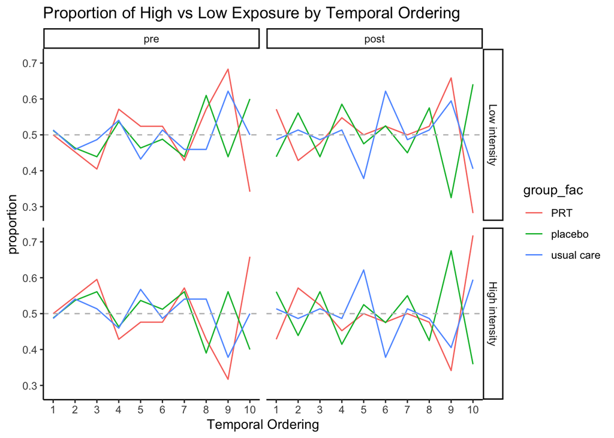

```r
# round(prop.table(table(df$intensity_fac, df$record_2, df$group_fac), margin=c(2,3)),2)
plt_order <-
    df %>%
    group_by(group_fac, time_fac, record_2) %>%
    summarize(prop_low_intensity = mean(intensity_fac == "low"),
              prop_high_intensity = 1-prop_low_intensity) %>%
    pivot_longer(cols=c("prop_low_intensity", "prop_high_intensity"),
                 names_to = "Intensity", values_to = "proportion") %>%
    mutate(Intensity = factor(Intensity, levels=c("prop_low_intensity","prop_high_intensity"),
                              labels=c("Low intensity","High intensity"))) %>%
    ggplot() +
    geom_line(aes(x=record_2, y=proportion, color=group_fac)) + facet_grid(Intensity~time_fac) +
    ggtitle("Proportion of High vs Low Exposure by Temporal Ordering") +
    xlab("Temporal Ordering") + scale_x_continuous(breaks=1:10) +
    geom_hline(yintercept=0.5, col='grey',lty=2)
plt_order
```

Looking at a heatmap of ordering at the indiviudal level, we seethat the ordering does appear to be random, with the apparent constraint that no more than 2 consecutive exposures can be of the same intensity

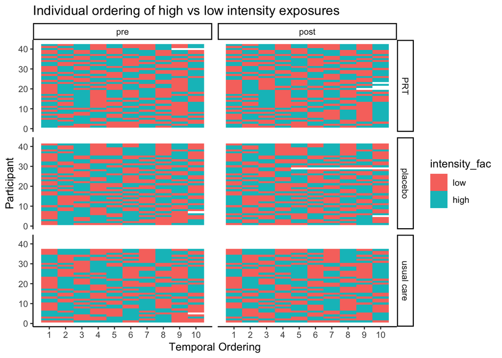

```r
plt_order_individual <-
    df %>%
    group_by(group_fac) %>%
    mutate(subject_fac = as.numeric(factor(Subject))) %>%
    ggplot() +
    geom_raster(aes(x=record_2, y=subject_fac, fill=intensity_fac)) +
    facet_grid(group_fac~time_fac) + ylab("Participant") + xlab("Temporal Ordering") +
    ggtitle("Individual ordering of high vs low intensity exposures") + scale_x_continuous(breaks=1:10)
plt_order_individual
```

```r
table(df$intensity_fac, df$Subject, df$time_fac)
```

```
## , ,  = pre
##
##
##        14 15 18 23 24 29 32 38 51 61 69 72 79 87 96 102 103 108 112 113 115 117
##   low   5  5  5  5  5  5  5  5  5  5  5  5  5  5  4   5   5   4   5   5   5   5
##   high  5  5  5  5  5  5  5  5  5  5  5  5  5  5  5   5   5   5   5   5   5   5
##
##        125 142 146 148 172 192 194 221 228 248 262 295 312 319 324 330 341 348
##   low    5   5   5   5   5   5   5   5   5   5   5   5   5   5   5   5   5   5
##   high   5   5   5   5   5   5   5   5   5   5   5   5   5   5   5   5   5   5
##
##        378 389 416 431 477 501 535 545 575 579 586 598 599 604 605 607 608 666
##   low    5   5   5   5   5   5   5   5   5   5   5   5   5   5   5   5   5   5
##   high   5   5   5   5   5   5   5   5   5   5   5   5   5   5   5   5   5   5
##
##        672 693 698 699 704 711 713 743 759 771 774 791 792 796 814 818 837 843
##   low    5   5   5   5   5   5   5   5   5   5   5   5   5   5   5   5   5   5
##   high   5   5   5   5   5   5   5   5   5   5   5   5   5   5   5   5   5   5
##
##        893 904 918 937 938 950 962 976 986 1015 1027 1029 1035 1036 1069 1078
##   low    5   5   5   5   5   5   5   5   5    5    5    5    5    5    5    5
##   high   5   5   5   5   5   5   5   5   5    5    5    5    5    5    5    5
##
##        1084 1087 1089 1099 1102 1103 1105 1108 1113 1122 1126 1141 1154 1159
##   low     5    5    5    5    5    5    5    5    5    5    5    4    5    5
##   high    5    5    5    5    5    5    5    5    5    5    5    4    5    5
##
##        1160 1169 1181 1211 1214 1231 1234 1239 1256 1268 1277 1294 1302 1319
##   low     5    5    5    5    5    5    5    5    5    5    5    5    5    5
##   high    5    5    5    5    5    5    5    5    5    5    5    5    5    5
##
## , ,  = post
##
##
##        14 15 18 23 24 29 32 38 51 61 69 72 79 87 96 102 103 108 112 113 115 117
##   low   5  5  5  5  5  5  5  5  5  5  5  5  5  5  5   5   5   5   5   5   5   5
##   high  5  5  5  5  5  5  5  5  5  5  4  5  5  5  5   5   5   5   5   5   5   5
##
##        125 142 146 148 172 192 194 221 228 248 262 295 312 319 324 330 341 348
##   low    5   5   5   5   5   5   5   5   5   5   5   5   5   5   5   5   5   5
##   high   5   5   5   5   5   5   5   5   5   5   5   5   5   5   5   5   5   5
##
##        378 389 416 431 477 501 535 545 575 579 586 598 599 604 605 607 608 666
##   low    5   5   5   5   5   5   5   5   5   5   5   5   5   4   5   5   5   5
##   high   5   5   5   5   5   5   5   5   5   5   5   5   5   4   4   5   5   5
##
##        672 693 698 699 704 711 713 743 759 771 774 791 792 796 814 818 837 843
##   low    5   5   5   5   5   5   5   5   5   5   5   5   5   5   5   5   5   5
##   high   5   5   5   4   5   5   5   5   5   5   5   5   5   5   5   5   5   5
##
##        893 904 918 937 938 950 962 976 986 1015 1027 1029 1035 1036 1069 1078
##   low    5   5   5   5   5   5   5   5   5    5    5    5    5    5    5    5
##   high   5   5   5   5   5   5   5   5   5    5    5    5    5    5    5    5
##
##        1084 1087 1089 1099 1102 1103 1105 1108 1113 1122 1126 1141 1154 1159
##   low     5    5    5    5    5    2    5    5    5    5    5    5    5    5
##   high    5    5    5    5    5    2    5    5    5    5    5    5    5    5
##
##        1160 1169 1181 1211 1214 1231 1234 1239 1256 1268 1277 1294 1302 1319
##   low     5    5    5    5    5    5    5    5    5    5    5    5    5    5
##   high    5    5    5    5    5    5    5    5    5    5    5    5    5    5
```

## 4.3 Plotting the outcome (pain score) data

### 4.3.1 Population Distributions

First, using boxplots, plot the distribution of pain intensity reported at pre and post periods (x-axis), stratified by low (left panel) vs high exposure (right panel) for each trial arm (color). We see that at baseline (pre) participants in the placebo and usual care arms tended to report lower pain than the PRT arm. Additionally, the difference appears to vary slightly by high vs low exposures. As a result, for our regression models, we will adjust for baseline group differences.

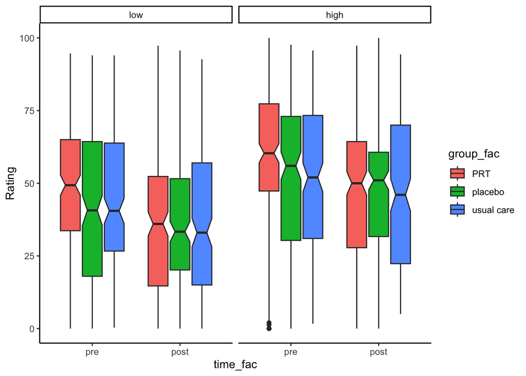

```r
df %>%
    ggplot() +
    geom_boxplot(aes(x=time_fac, y=Rating, fill=group_fac), notch=T) +
    facet_grid(~intensity_fac)
```

If we look at the distribution of outcomes by temporal ordering of exposure, there doesn’t appear to be a strong trend, though there is some evidence that average reported pain increases for later high intensity exposures (note the median of the blue boxplots tends to increase slightly across pre and post periods for each trial arm).

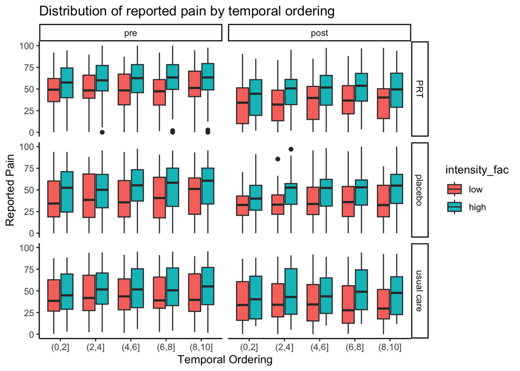

```r
plt_dist_pop <-
    df %>%
    mutate(record_2_fac = cut(record_2, c(0, 2, 4, 6, 8, 10))) %>%
    ggplot() +
    geom_boxplot(aes(x=factor(record_2_fac), y=Rating, fill=intensity_fac)) +
    facet_grid(group_fac~time_fac) +
    xlab("Temporal Ordering") + ylab("Reported Pain") +
    ggtitle("Distribution of reported pain by temporal ordering")
plt_dist_pop
```

Given the bounded nature of the data, we are also concerned with potential the potential for a strong mean-variance relationship which would violate the heterskedasticity assumption of linear regression. To assess this, several figures were considered. First, the mean and standard deviation of report pain was stratified by the $q^{th}$ percentiles of the data ($q \in 10, 20, 40, 60, 80, 90, 100$) and temporal ordering (intensity was also considered but no meaningful trends emerged and so the results are not included here).

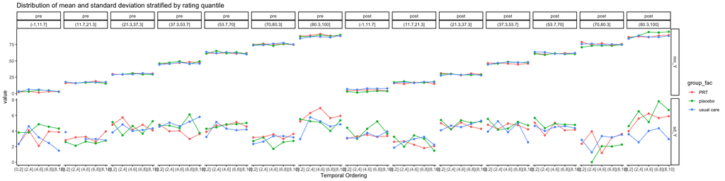

```r
plt_dist_summ <-
    df %>%
    mutate(record_2_fac = cut(record_2, c(0, 2, 4, 6, 8, 10)),
           record_2_fac_num = as.numeric(record_2_fac)) %>%
    mutate(rating_quintile = cut(Rating, c(-1, quantile(Rating, c(0.1,0.2, 0.4, 0.6, 0.8,0.9)), 100))) %>%
    # group_by(rating_quintile, group_fac, time_fac, intensity_fac, record_2_fac_num) %>%
    group_by(rating_quintile, group_fac, time_fac, record_2_fac_num) %>%
    summarize(mn_Y = mean(Rating),
              sd_Y = sd(Rating)) %>%
    ungroup() %>%
    pivot_longer(cols=c("mn_Y","sd_Y"), names_to="measure") %>%
    ggplot(aes(x=record_2_fac_num, y=value, color=group_fac)) +
    geom_point() + geom_line() + scale_x_continuous(breaks=c(1:5),labels=c("(0,2]","(2,4]","(4,6]","(6,8]","(8,10]")) +
    facet_grid(measure~time_fac + rating_quintile, scales="free_y") +
    ggtitle("Distribution of mean and standard deviation stratified by rating quantile") +
    xlab("Temporal Ordering")
plt_dist_summ
```

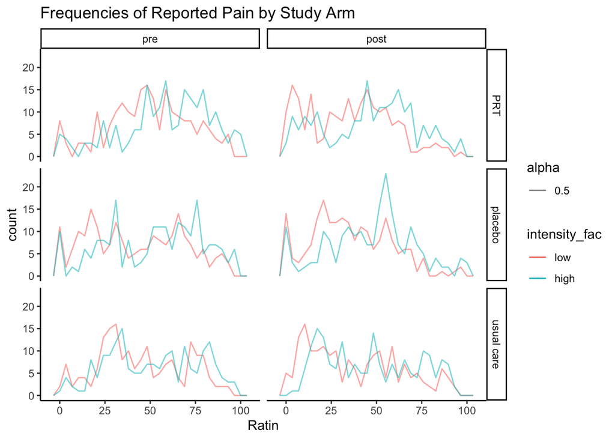

```r
df %>%
    ggplot() +
    geom_freqpoly(aes(x=Rating, color=intensity_fac, alpha=0.5)) +
    facet_grid(group_fac~time_fac) + ggtitle("Frequencies of Reported Pain by Study Arm") +
    xlab("Ratin")
```

### 4.3.2 Individual level EDA

#### 4.3.2.1 Trajectories

```r
df %>%
    group_by(Subject, time_fac) %>%
    mutate(mn_rating_pre = mean(Rating[time_fac == "pre"])) %>%
    ungroup() %>%
    group_by(group_fac) %>%
    arrange(mn_rating_pre, time_fac, record_2) %>%
    mutate(subj_group_plot = 4)
```

```
## # A tibble: 2,385 × 15
## # Groups:   group_fac [3]
##    Subject Group  Time Intensity Rating group_fac time_fac intensity_fac record
##      <dbl> <dbl> <dbl>     <dbl>  <dbl> <fct>     <fct>    <fct>          <dbl>
##  1     976     2     0         2      0 placebo   pre      high               1
##  2     976     2     0         1      0 placebo   pre      low                2
##  3     976     2     0         1      0 placebo   pre      low                3
##  4     976     2     0         2      0 placebo   pre      high               4
##  5     976     2     0         2      0 placebo   pre      high               5
##  6     976     2     0         1      0 placebo   pre      low                6
##  7     976     2     0         2      0 placebo   pre      high               7
##  8     976     2     0         1      0 placebo   pre      low                8
##  9     976     2     0         1      0 placebo   pre      low                9
## 10     976     2     0         2      0 placebo   pre      high              10
## # ℹ 2,375 more rows
## # ℹ 6 more variables: record_2 <int>, Subject_fac <fct>, Subject_time <chr>,
## #   Subject_time_fac <fct>, mn_rating_pre <dbl>, subj_group_plot <dbl>
```

#### 4.3.2.2 Participant level variation

Calculating participant specific averages and standard deviation of reported pain, we see further evidence that variability (generally) exhibits an inverted U shaped association with participant averages. However, there does appear to be some bimodality in the mean-variance relationship in the PRT group in the post-intervention period for *high* exposures.

An additional point to note is that we see substantial variability in participants’ reported pain. Our model should therefore consider modelling these sources of heterogeneous variability in some fashion.

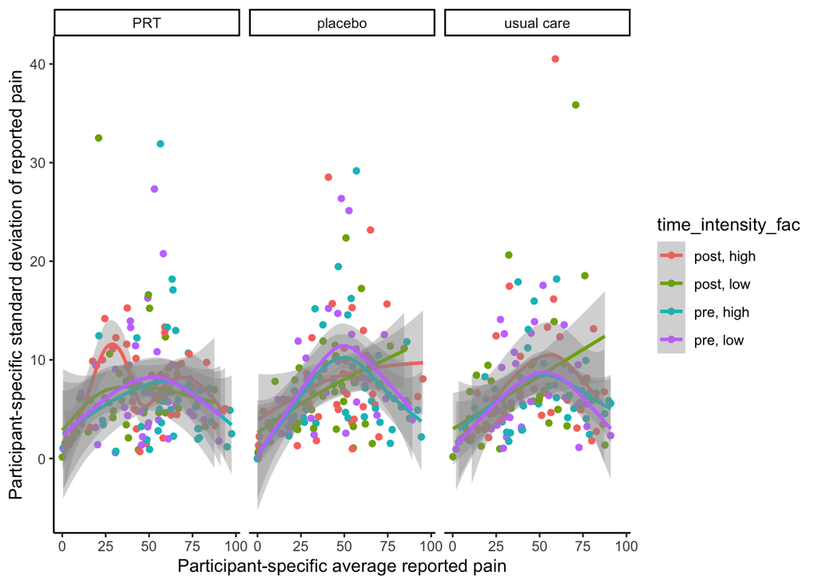

```r
df %>%
    group_by(Subject, intensity_fac, time_fac) %>%
    summarize(mn_Y = mean(Rating),
              sd_Y = sd(Rating),
              group_fac=group_fac[1]) %>%
    ungroup() %>%
    mutate(time_intensity_fac = paste0(time_fac, ", ", intensity_fac)) %>%
    ggplot() +
    geom_point(aes(x=mn_Y, y=sd_Y, color=time_intensity_fac)) +
    facet_grid(~group_fac, scales="free_y") +
    geom_smooth(aes(x=mn_Y, y=sd_Y, color=time_intensity_fac), method="gam", formula=y~s(x,bs="cr",k=10)) +
    ylab("Participant-specific standard deviation of reported pain") +
    xlab("Participant-specific average reported pain")
```

Next we examine the correlation of participants’ average and variability of reported pain between the pre and post periods. The figure below shows that pre and post average reported pain are positively correlated, though some notable exceptions are clearly present. For example there are 3 participants (one in each trial arm) who report effectively 0 pain at baseline for high and low exposures, but relatively high levels of pain at the post-intervention assessment. Additionally, one participant in the placebo group reported high pain at baseline, but effectively 0 post-intervention. The data for these participants are plotted for reference.

Lastly, note that the correlation between average pre and post ratings appears relatively consistent across the groups and is approximately linear (barring the influence of potential outlying points).

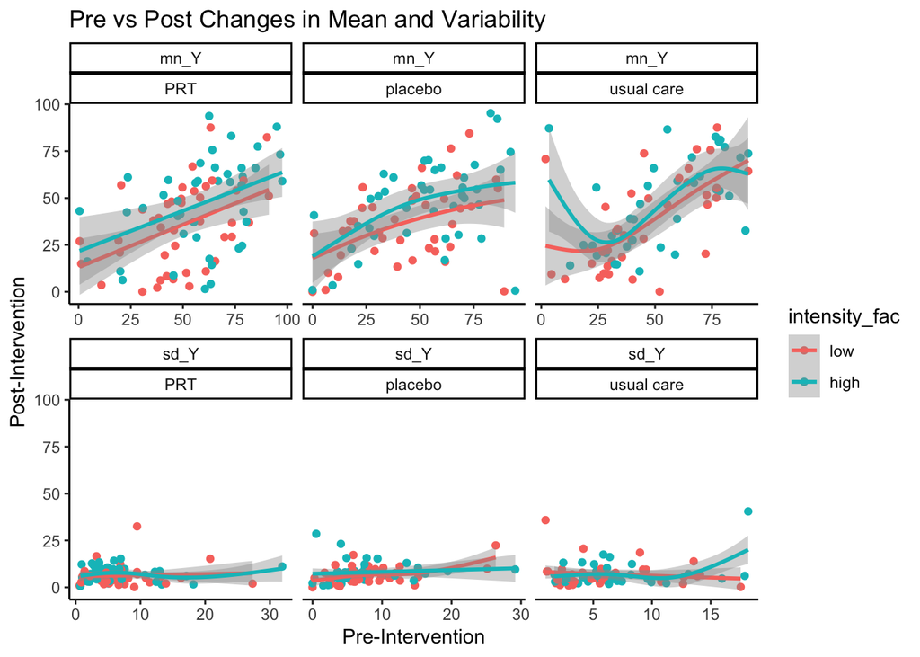

```r
df %>%
    group_by(Subject, intensity_fac, time_fac) %>%
    summarize(mn_Y = mean(Rating),
              sd_Y = sd(Rating),
              group_fac=group_fac[1]) %>%
    ungroup() %>%
    pivot_longer(cols=c("mn_Y","sd_Y"), names_to="measure") %>%
    pivot_wider(names_from="time_fac", values_from = "value") %>%
    # mutate(time_intensity_fac = paste0(time_fac, ", ", intensity_fac)) %>%
    ggplot() +
    geom_point(aes(x=pre, y=post, color=intensity_fac)) +
    facet_wrap(measure~group_fac, scales="free_x",ncol=3) +
    geom_smooth(aes(x=pre, y=post, color=intensity_fac), method="gam", formula=y~s(x,bs="cr",k=10)) +
    ylab("Post-Intervention") +
    xlab("Pre-Intervention") + ggtitle("Pre vs Post Changes in Mean and Variability")
```

[figure not shown]

```r
df %>%
    filter(Subject %in% c(904, 1029, 1103, 1231)) %>%
    mutate(Subject_group = paste0("ID ", Subject, ", ", group_fac)) %>%
    ggplot() +
    geom_point(aes(x=record_2, y=Rating, color=intensity_fac)) +
    facet_grid(Subject_group~time_fac) +
    geom_line(aes(x=record_2, y=Rating, color=intensity_fac)) +
    ylab("Temporal Ordering") +
    xlab("Rating") + ggtitle("Trajectories for outlying participants")
```